# Tutorial 11 - Analysis of repeated measures

with solutions

Note: you can download the .Rmd file using the ‘code’ button on the top right.

# Setup

```r
library(tidyverse)
library(rstatix)
library(ggpubr)
library(glmmTMB)
library(marginaleffects)
library(patchwork)
theme_set(theme_bw())
```

# Analysis of pain data

In this tutorial we’ll analyse the data from an experiment on how long the analgesic effects of a drug last on five participants. Pain was measured three times: initially at 3 PM, then at 5 PM, and lastly at 7 PM.

`Pain` is the response vairiable, ranging from 0 = ‘no pain’ to 100 = ‘worst possible pain’.

`Time` (3 PM, 5 PM, 7 PM) is a fixed effect (within subject variable).

`Subject` is a random effect, crossed with `Time` (which is a fixed effect).

We will analyse this data first with repeated-measures Analysis of Variance, using `rstatix` package, and then we’ll move on to modern mixed models, using the `glmmTMB` package.

# 1 Enter the dataset and fit the models from the first part of the tutorial

First, enter the data into R as a `tibble` in long format.

```r
dt <- tibble(
    Subject = as_factor(rep(1:5,each=3)),
    Time = as_factor(rep(c("3 PM","5 PM","7 PM"),5)),
    Pain = c(45, 50, 55, 42, 42, 45, 36, 41, 43, 39, 36, 40, 51, 55, 59)) |>
  # reorder subject by their pain scores
  mutate(Subject = fct_reorder(Subject,-Pain,mean)) |>
  # make another version of time: hours = hours since start of experiment
  mutate(Hour = (as.numeric(Time) - 1) * 2)
dt
```

| Subject | Time | Pain | Hour |
| --- | --- | --- | --- |
| 1 | 3 PM | 45 | 0 |
| 1 | 5 PM | 50 | 2 |
| 1 | 7 PM | 55 | 4 |
| 2 | 3 PM | 42 | 0 |
| 2 | 5 PM | 42 | 2 |
| 2 | 7 PM | 45 | 4 |
| 3 | 3 PM | 36 | 0 |
| 3 | 5 PM | 41 | 2 |
| 3 | 7 PM | 43 | 4 |
| 4 | 3 PM | 39 | 0 |

[output cut: 5 more lines]

```r
lmm1 <- glmmTMB(Pain ~ Time + (1 | Subject), data=dt)

lmm2 <- glmmTMB(Pain ~ Time + cs(0 + Time | Subject),
                  dispformula=~0, data=dt)

lmm3 <- glmmTMB(Pain ~ Hour + (1 | Subject), data = dt)

mixreg1 <- glmmTMB(Pain ~ Hour + (Hour | Subject), data = dt)

mixreg2 <- glmmTMB(
  Pain ~ Hour + (1 | Subject) + (0 + Hour | Subject),
  data = dt)
```

# 2 Exercise: revisiting the mixed model with `Time` as a factor

Now, let’s fit to this dataset some of the other mixed models that we fit to the arthritis dataset in the lecture for week 11.

1. Fit two mixed models with varying effects of subject, where the effects of subject are different among times ($b_{ij}$, instead of $b_j$). Fit this model with
- a compound symmetric variance-covariance matrix (model `lmm2` in the lecture), and
- an unstructured variance-covariance matrix (model `lmm3` in the lecture).

Remember, you’re now fitting 5 x 3 = 15 subject effects, so be sure to remove the error term from the model!

2. Compare the mixed models using `anova`. Which of these models is ‘best’?
3. Plot some of the predictions from the best `lmmx` model.
4. Finally, compare the best `lmmx` model to the `mixreg2` model.

# 3 Solutions to Exercise

## 3.1 Fit models

### 3.1.1 Fit the compound-symmetry-covariance model

```r
lmm2 <- glmmTMB(Pain ~ Time + cs(0 + Time | Subject),
                  dispformula=~0, data=dt)

summary(lmm2)
```

```
##  Family: gaussian  ( identity )
## Formula:          Pain ~ Time + cs(0 + Time | Subject)
## Dispersion:            ~0
## Data: dt
##
##      AIC      BIC   logLik deviance df.resid
##     90.1     95.1    -38.1     76.1        8
##
## Random effects:
##
## Conditional model:
##  Groups  Name     Variance Std.Dev. Corr
##  Subject Time3 PM 27.66    5.259    0.93 (cs)
##          Time5 PM 45.63    6.755
##          Time7 PM 52.12    7.219
## Number of obs: 15, groups:  Subject, 5
##
## Conditional model:
##             Estimate Std. Error z value Pr(>|z|)
## (Intercept)   42.600      2.352   18.11  < 2e-16 ***
## Time5 PM       2.200      1.177    1.87   0.0615 .
## Time7 PM       5.800      1.330    4.36  1.3e-05 ***
## ---
## Signif. codes:  0 '***' 0.001 '**' 0.01 '*' 0.05 '.' 0.1 ' ' 1
```

### 3.1.2 Fit the unstructured-covariance model

```r
lmm3 <- glmmTMB(Pain ~ Time + us(0 + Time | Subject),
                  dispformula=~0, data=dt)

summary(lmm3)
```

```
##  Family: gaussian  ( identity )
## Formula:          Pain ~ Time + us(0 + Time | Subject)
## Dispersion:            ~0
## Data: dt
##
##      AIC      BIC   logLik deviance df.resid
##     85.6     91.9    -33.8     67.6        6
##
## Random effects:
##
## Conditional model:
##  Groups  Name     Variance Std.Dev. Corr
##  Subject Time3 PM 26.64    5.161
##          Time5 PM 46.16    6.794    0.89
##          Time7 PM 53.44    7.310    0.92 0.99
## Number of obs: 15, groups:  Subject, 5
##
## Conditional model:
##             Estimate Std. Error z value Pr(>|z|)
## (Intercept)   42.600      2.308  18.456  < 2e-16 ***
## Time5 PM       2.200      1.425   1.543    0.123
## Time7 PM       5.800      1.481   3.917 8.95e-05 ***
## ---
## Signif. codes:  0 '***' 0.001 '**' 0.01 '*' 0.05 '.' 0.1 ' ' 1
```

## 3.2 Compare models

First, we’ll compare the mixed ANOVA models.

```r
anova(lmm1,lmm2,lmm3)
```

|  | Df | AIC | BIC | logLik | deviance | Chisq | Chi Df | Pr(>Chisq) |
| --- | --- | --- | --- | --- | --- | --- | --- | --- |
| lmm1 | 5 | 89.52290 | 93.06315 | -39.76145 | 79.52290 | NA | NA | NA |
| lmm2 | 7 | 90.11267 | 95.06902 | -38.05633 | 76.11267 | 3.410234 | 2 | 0.18175116 |
| lmm3 | 9 | 85.55530 | 91.92775 | -33.77765 | 67.55530 | 8.557369 | 2 | 0.01386088 |

It looks like model `lmm3`, with the unstructured covariance matrix, is the best here. It has the lowest AIC score, and is significantly better than the model with the compound-symmetric covariance matrix (`lmm2`).

We might also compare the unstructured-covariance model to the mixed-regression model we fit earlier.

```r
anova(mixreg2,lmm3)
```

|  | Df | AIC | BIC | logLik | deviance | Chisq | Chi Df | Pr(>Chisq) |
| --- | --- | --- | --- | --- | --- | --- | --- | --- |
| mixreg2 | 5 | 87.78477 | 91.32502 | -38.89238 | 77.78477 | NA | NA | NA |
| lmm3 | 9 | 85.55530 | 91.92775 | -33.77765 | 67.55530 | 10.22947 | 4 | 0.0367347 |

It looks like the largest model here (`lmm3`) wins again.

Model `lmm3` fits a unique within-subject correlations for each pair of time steps is the winner. You can see these correlations under `Corr` in the `summary()` output.

```r
summary(lmm3)
```

```
##  Family: gaussian  ( identity )
## Formula:          Pain ~ Time + us(0 + Time | Subject)
## Dispersion:            ~0
## Data: dt
##
##      AIC      BIC   logLik deviance df.resid
##     85.6     91.9    -33.8     67.6        6
##
## Random effects:
##
## Conditional model:
##  Groups  Name     Variance Std.Dev. Corr
##  Subject Time3 PM 26.64    5.161
##          Time5 PM 46.16    6.794    0.89
##          Time7 PM 53.44    7.310    0.92 0.99
## Number of obs: 15, groups:  Subject, 5
##
## Conditional model:
##             Estimate Std. Error z value Pr(>|z|)
## (Intercept)   42.600      2.308  18.456  < 2e-16 ***
## Time5 PM       2.200      1.425   1.543    0.123
## Time7 PM       5.800      1.481   3.917 8.95e-05 ***
## ---
## Signif. codes:  0 '***' 0.001 '**' 0.01 '*' 0.05 '.' 0.1 ' ' 1
```

What do those correlations represent?

This model fits random effects for each Subject *for each Time point*.

Let’s look at the random effects.

```r
ranef(lmm3)
```

```
## $Subject
##     Time3 PM  Time5 PM  Time7 PM
## 5  8.4000014 10.200003 10.600003
## 1  2.4000014  5.200003  6.600003
## 2 -0.5999986 -2.799997 -3.399997
## 3 -6.5999986 -3.799997 -5.399997
## 4 -3.5999986 -8.799997 -8.399997
```

The pain score for Subject 5 at 3 PM (i.e., 51) is 8.4 units above the average of the 3 PM pain scores.

The average of the 3 PM pain scores is 42.6.

42.6 + 8.4 = 51.

```r
dt |> filter(Subject==5 & Time == "3 PM") |> pull(Pain)
```

```
## [1] 51
```

When you look at the random effects of subjects, you can see that the three columns are correlated with each other. The subjects with the larger random effects at 3 PM tend to have the larger random effects at 5 PM and 7 PM. *Those are the correlations that are captured by the correlation matrix.*

If we take the random effects matrix and calculate the correlations, we can reproduce the correlations that appear in the summary output.

```r
ranef(lmm3)$cond$Subject |> cor() |> round(2)
```

```
##          Time3 PM Time5 PM Time7 PM
## Time3 PM     1.00     0.89     0.92
## Time5 PM     0.89     1.00     0.99
## Time7 PM     0.92     0.99     1.00
```

## 3.3 Plot predictions for `lmm3`

Let’s make a plot of the means for each time, with the points coloured by subject.

First, we’ll get the estimates of means and confidence intervals. Here, I’ve used the `ggeffects` package, but there are other ways.

```r
library(ggeffects)

gge_lmm3 <- ggpredict(
  lmm3,
  terms = "Time",
  type = "fixed",
  interval = "confidence"
  )

gge_lmm3
```

| x | predicted | std.error | conf.low | conf.high | group |
| --- | --- | --- | --- | --- | --- |
| 3 PM | 42.6 | 2.308247 | 38.07592 | 47.12408 | 1 |
| 5 PM | 44.8 | 3.038421 | 38.84480 | 50.75519 | 1 |
| 7 PM | 48.4 | 3.269252 | 41.99238 | 54.80761 | 1 |

Here’s an easy way to make a plot.

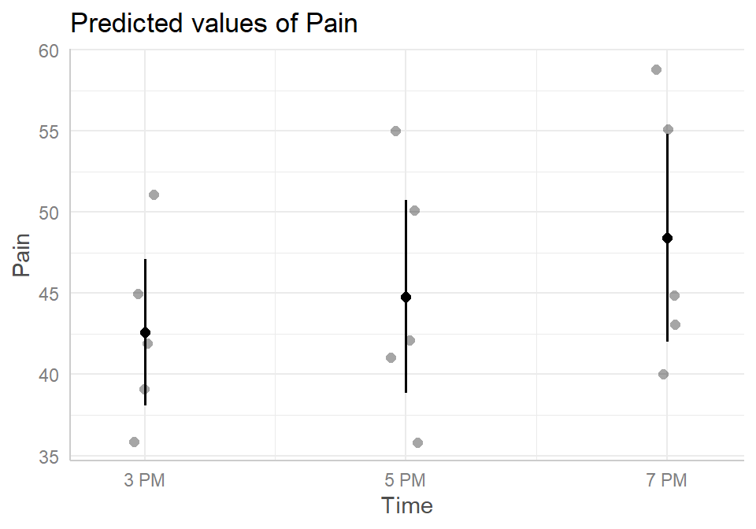

```r
plot(gge_lmm3, add.data = T, jitter = T)
```

To make a more sophisticated plot (with points coloured by Subjects), we’ll need to do it by hand.

First, convert the `ggeffects` object into a dataframe.

```r
gge_lmm3_df <- gge_lmm3 |> as.data.frame()
```

And now make a plot of the predictions and then add the points.

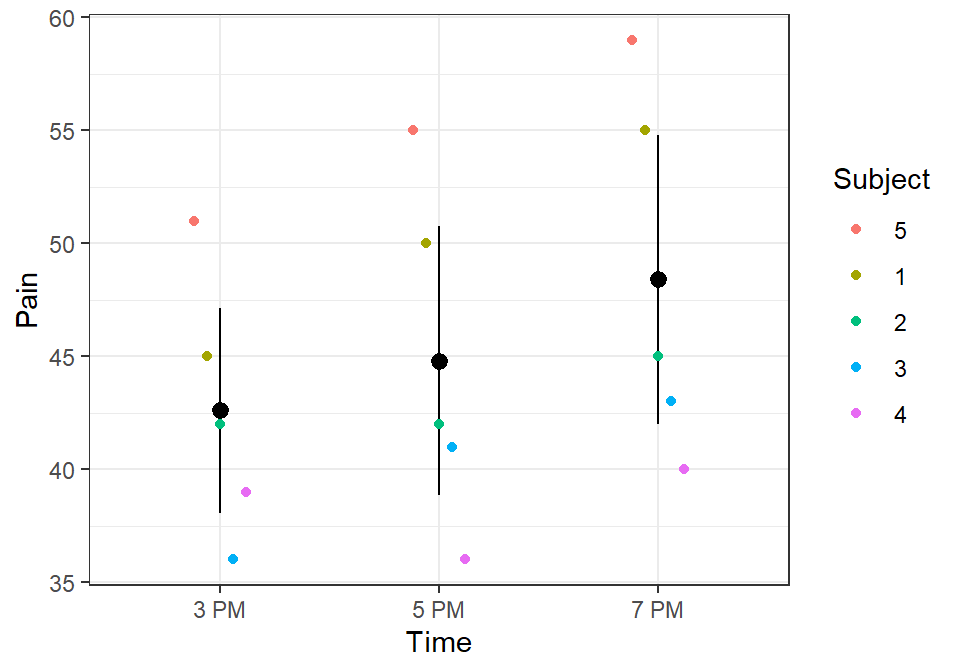

```r
ggplot() +

  # add predicted values as points and error bars
  geom_pointrange(
    data = gge_lmm3_df,
    mapping = aes(
      x = x,
      y = predicted,
      ymin = conf.low,
      ymax = conf.high)
  ) +

  # add original data points coloured by Subjects
  geom_point(
    data = dt,
    mapping = aes(
      x = Time,
      y = Pain,
      colour = Subject),
    position = position_dodge(width = .3)
    ) +

  # add axis labels
  xlab("Time") +
  ylab("Pain")
```